# CSC498H Final Project: Real World Problem

Loay Halawani (ID: 202001879), Yasmina El Ayache (ID: 202004411), Mohammad Jaber (ID: 202005688)

2023-12-10

# Part 1: Problem Selection

Prolonged exposure to high blood sugar levels damages retinal blood vessels, which leads to diabetic retinopathy, one of the main causes of blindness in individuals with diabetes. The manual inspection process used in traditional screening procedures by ophthalmologists takes a lot of time and resources. By using machine learning models for early detection, screening effectiveness is increased, allowing for prompt intervention to halt the progression of the disease. Benefits include reduced risk of vision impairment, early intervention, affordable screening, enhanced accessibility, efficient use of resources, and scalability to meet the increased prevalence of diabetes worldwide. All things considered, a machine learning approach supports public health objectives by resolving a pressing problem and improving healthcare effectiveness.

# Part 2: Dataset Selection

```r
# Read the dataset into a dataframe
data <- read.csv("diabetes.csv", header = T, na.strings = "?")

# Column names
colnames(data) <- c("Pregnancies", "Glucose", "BloodPressure", "SkinThickness", "Insulin", "BMI", "DiabetesPedigreeFunction", "Age", "Outcome")
```

In the above code, we import the dataset and specify its column names.

```r
# Number of observations
num_observations <- nrow(data)
cat("Number of Observations:", num_observations)
```

```
## Number of Observations: 768
```

In the above code, we display the total number of observations in the dataset.

```r
# Number of features
num_features <- ncol(data)
cat("\nNumber of Features:", num_features)
```

```
##
## Number of Features: 9
```

In the above code, we display the total number of features in the dataset. Below is an explanation of each feature.

- Pregnancies: To express the number of pregnancies.
- Glucose: To express the level of glucose in the blood.
- BloodPressure: To express the blood pressure measurement.
- SkinThickness: To express the thickness of the skin.
- Insulin: To express the level of insulin in the blood.
- BMI: To express the value of the Body Mass Index.
- DiabetesPedigreeFunction: To express the percentage of diabetes.
- Age: To express the age.
- Outcome: To express the final result, where 1 is diabetic and 0 is non-diabetic.

# Part 3: Data Exploration

```r
# Summary of the data
summary(data)
```

```
##   Pregnancies        Glucose      BloodPressure    SkinThickness
##  Min.   : 0.000   Min.   :  0.0   Min.   :  0.00   Min.   : 0.00
##  1st Qu.: 1.000   1st Qu.: 99.0   1st Qu.: 62.00   1st Qu.: 0.00
##  Median : 3.000   Median :117.0   Median : 72.00   Median :23.00
##  Mean   : 3.845   Mean   :120.9   Mean   : 69.11   Mean   :20.54
##  3rd Qu.: 6.000   3rd Qu.:140.2   3rd Qu.: 80.00   3rd Qu.:32.00
##  Max.   :17.000   Max.   :199.0   Max.   :122.00   Max.   :99.00
##     Insulin           BMI        DiabetesPedigreeFunction      Age
##  Min.   :  0.0   Min.   : 0.00   Min.   :0.0780           Min.   :21.00
##  1st Qu.:  0.0   1st Qu.:27.30   1st Qu.:0.2437           1st Qu.:24.00
##  Median : 30.5   Median :32.00   Median :0.3725           Median :29.00
##  Mean   : 79.8   Mean   :31.99   Mean   :0.4719           Mean   :33.24
##  3rd Qu.:127.2   3rd Qu.:36.60   3rd Qu.:0.6262           3rd Qu.:41.00
##  Max.   :846.0   Max.   :67.10   Max.   :2.4200           Max.   :81.00
##     Outcome
##  Min.   :0.000
##  1st Qu.:0.000
##  Median :0.000
##  Mean   :0.349
##  3rd Qu.:1.000
##  Max.   :1.000
```

In the above code, we explore the data by displaying a summary that shows the min, max, median (Q2), mean, Q1, and Q3 values of each feature.

```r
# Structure of the data
str(data)
```

```
## 'data.frame':    768 obs. of  9 variables:
##  $ Pregnancies             : int  6 1 8 1 0 5 3 10 2 8 ...
##  $ Glucose                 : int  148 85 183 89 137 116 78 115 197 125 ...
##  $ BloodPressure           : int  72 66 64 66 40 74 50 0 70 96 ...
##  $ SkinThickness           : int  35 29 0 23 35 0 32 0 45 0 ...
##  $ Insulin                 : int  0 0 0 94 168 0 88 0 543 0 ...
##  $ BMI                     : num  33.6 26.6 23.3 28.1 43.1 25.6 31 35.3 30.5 0 ...
##  $ DiabetesPedigreeFunction: num  0.627 0.351 0.672 0.167 2.288 ...
##  $ Age                     : int  50 31 32 21 33 30 26 29 53 54 ...
##  $ Outcome                 : int  1 0 1 0 1 0 1 0 1 1 ...
```

In the above code, we check the structure of the data that shows the type of each variable (integer, decimal, string etc.).

```r
# First few rows of the dataset
head(data)
```

```
##   Pregnancies Glucose BloodPressure SkinThickness Insulin  BMI
## 1           6     148            72            35       0 33.6
## 2           1      85            66            29       0 26.6
## 3           8     183            64             0       0 23.3
## 4           1      89            66            23      94 28.1
## 5           0     137            40            35     168 43.1
## 6           5     116            74             0       0 25.6
##   DiabetesPedigreeFunction Age Outcome
## 1                    0.627  50       1
## 2                    0.351  31       0
## 3                    0.672  32       1
## 4                    0.167  21       0
## 5                    2.288  33       1
## 6                    0.201  30       0
```

In the above code, we display the first few rows of the dataset.

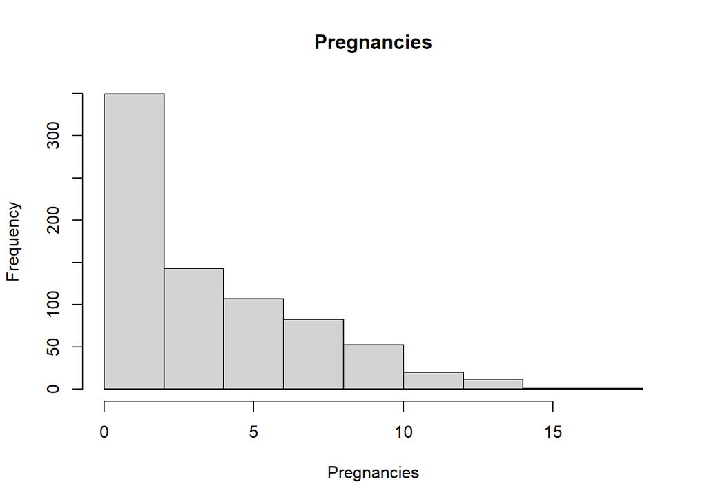

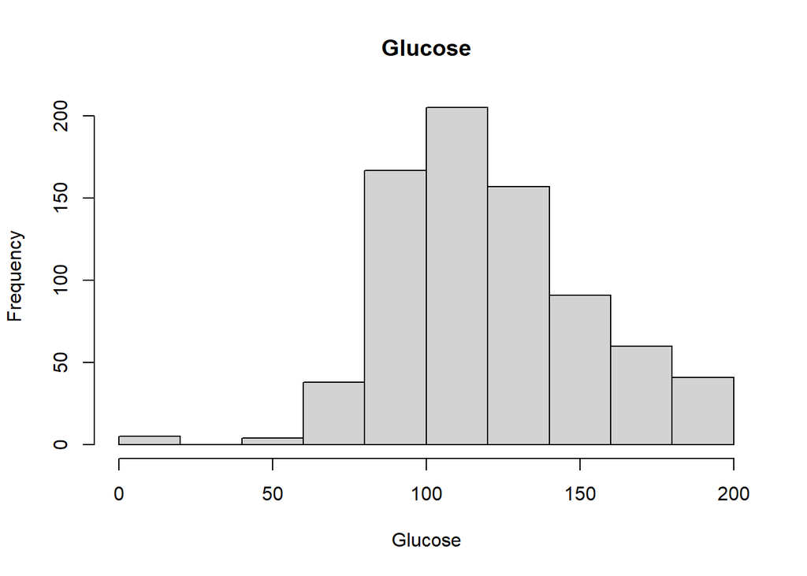

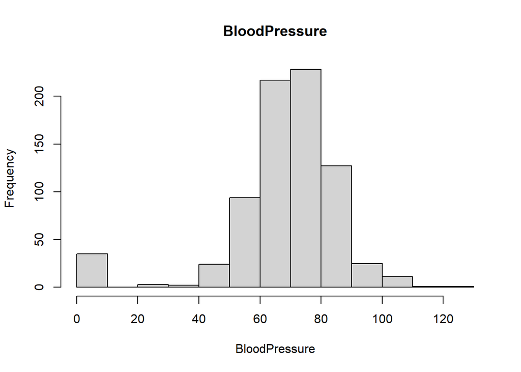

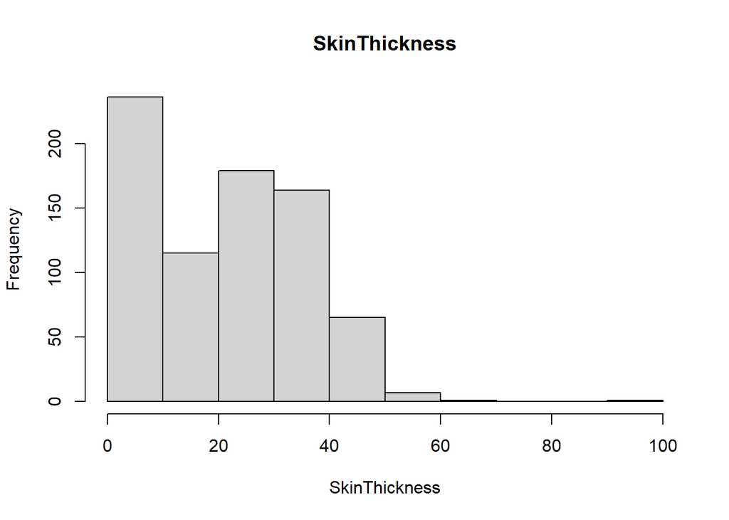

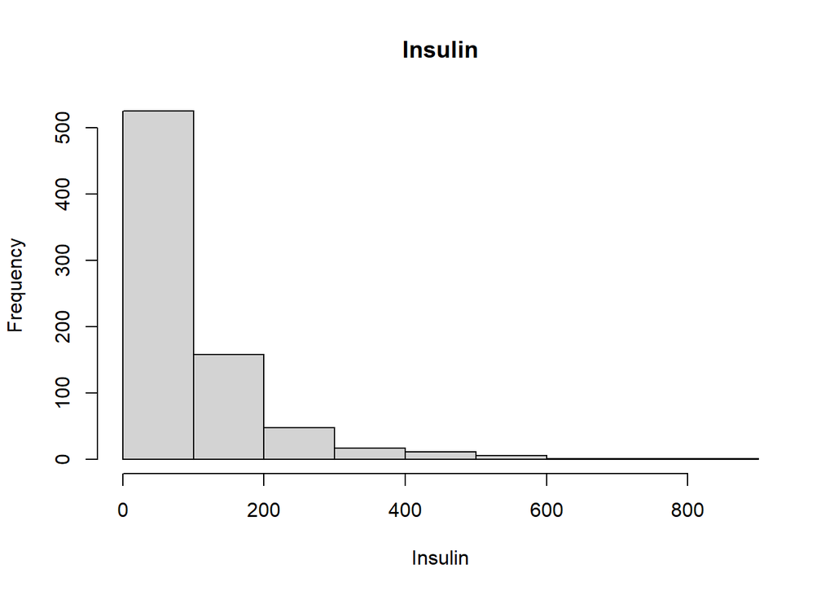

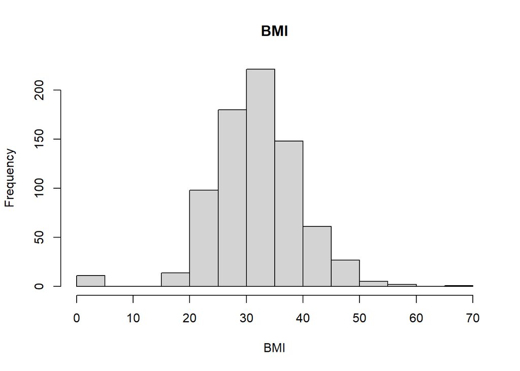

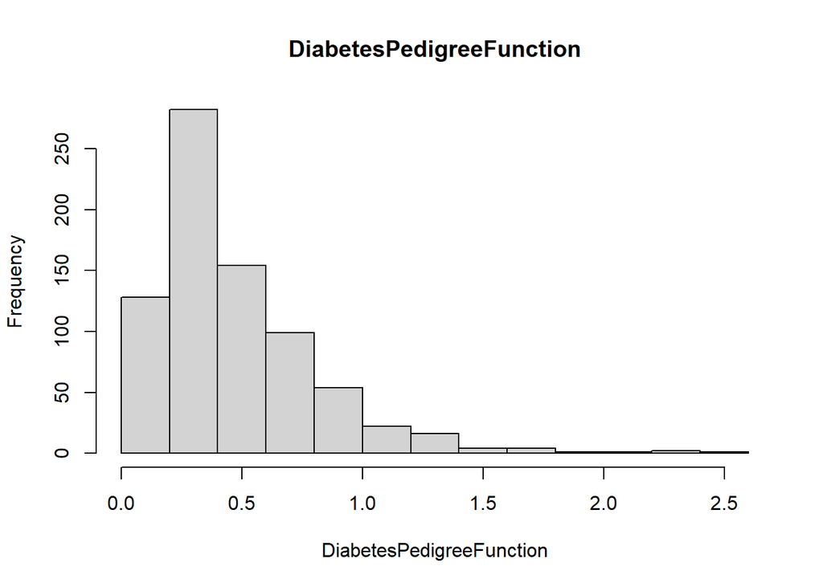

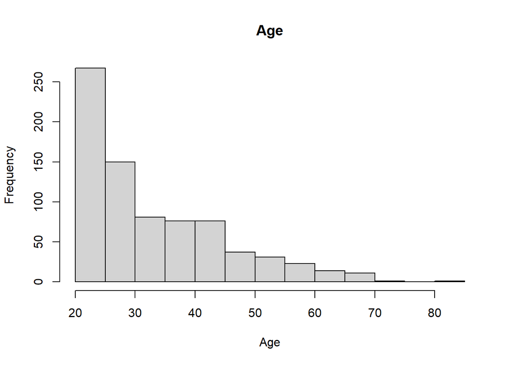

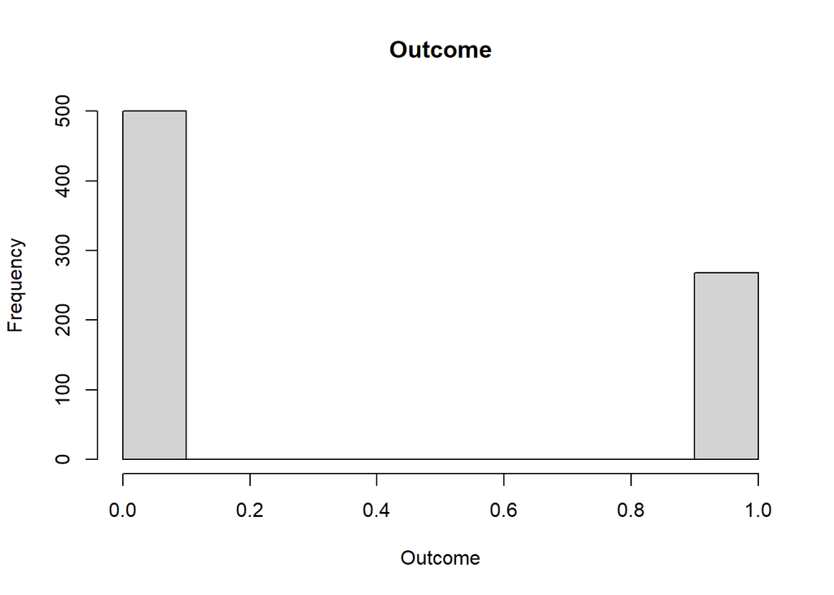

```r
# Histogram of each feature
for(col in colnames(data)) {
  hist(data[[col]], main=col, xlab=col)
}
```


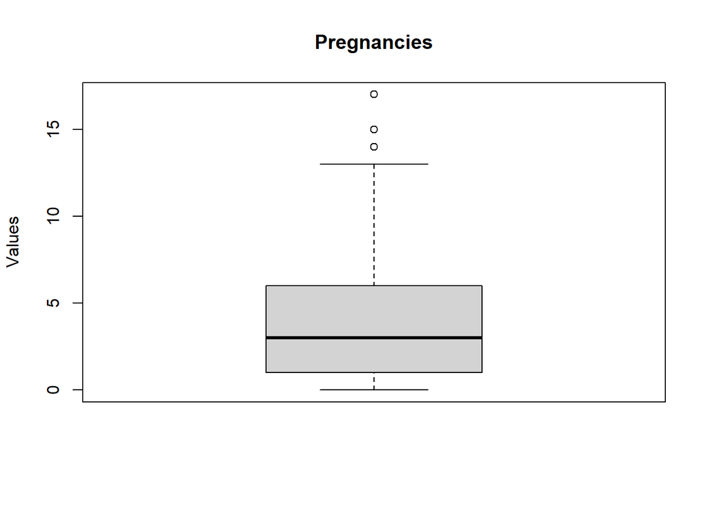

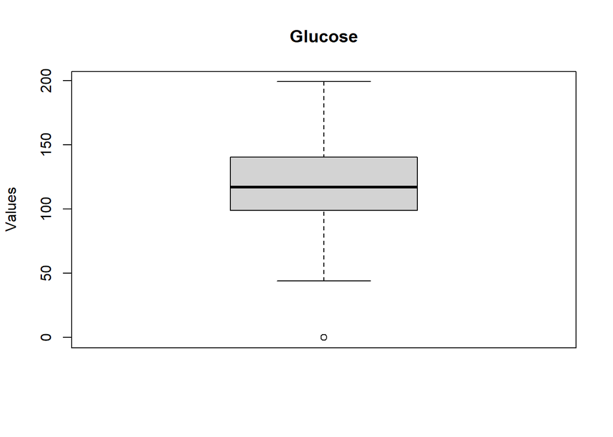

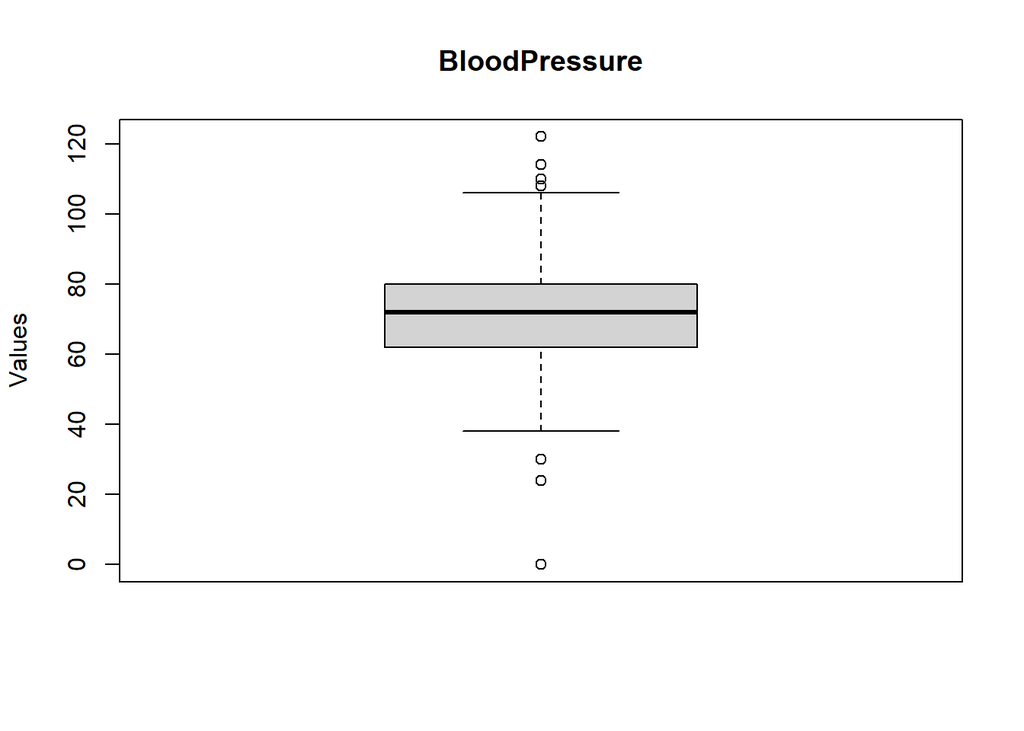

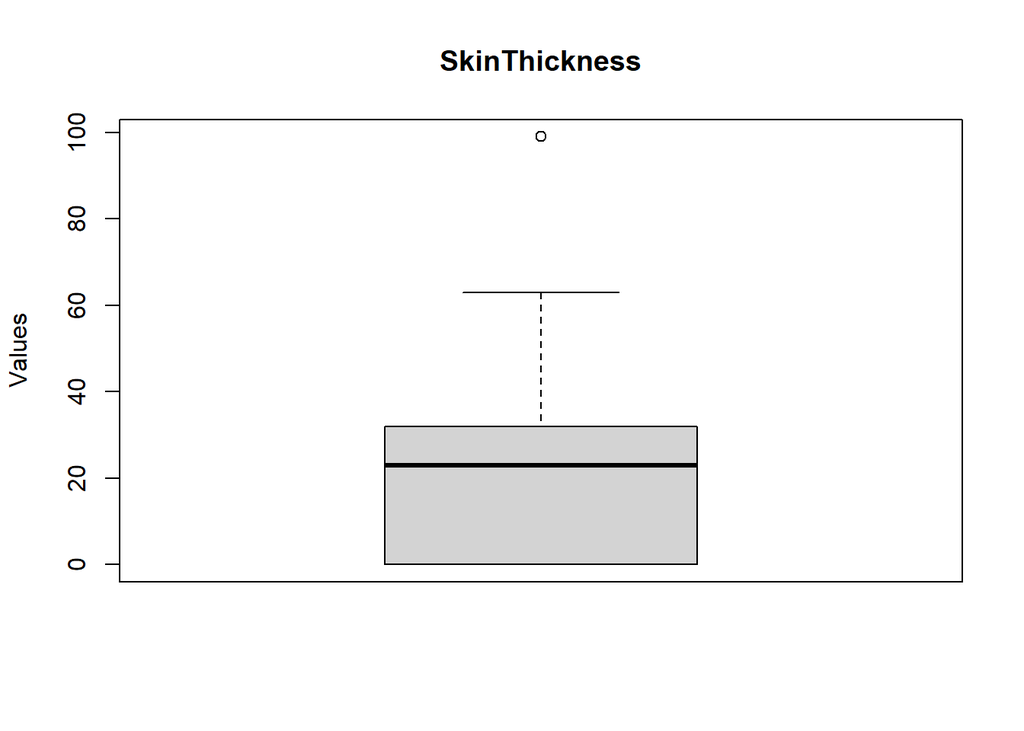

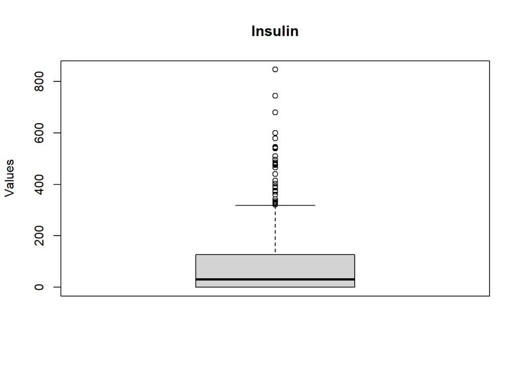

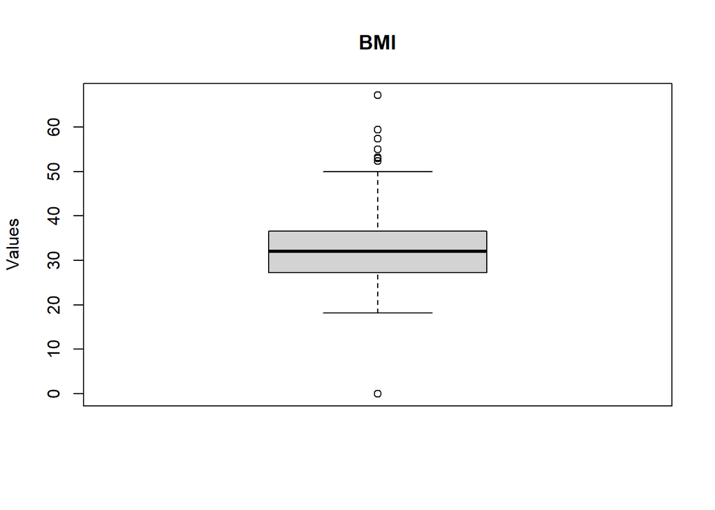

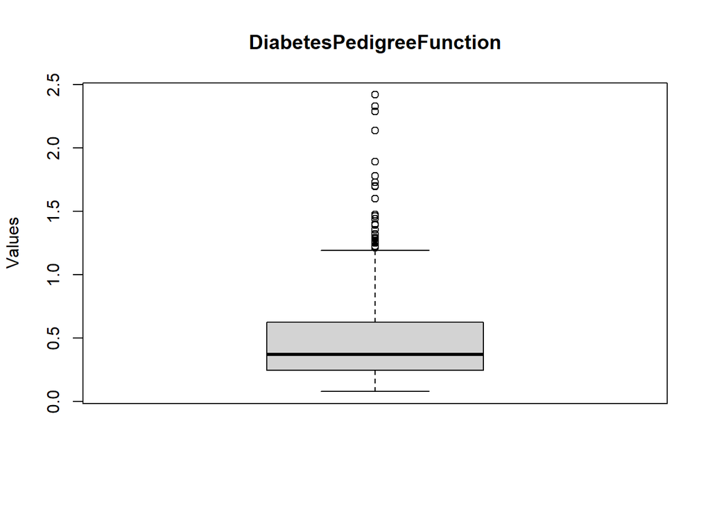

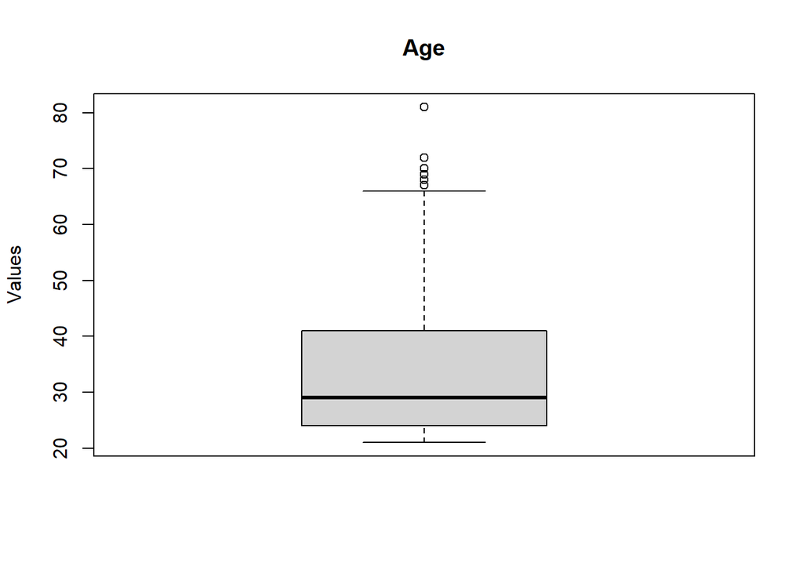

```r
# Boxplot of each feature
for (col in colnames(data)) {
  if (col != "Outcome")
  boxplot(data[[col]], main=col, ylab="Values", outline=TRUE)
}
```

In the above code, we plot a boxplot of each feature in the dataset. As we can see, all the boxplots indicate the presence of outliers in the dataset.

# Part 4: Data Preprocessing

```r
# Missing values in each column
missing_values <- colSums(is.na(data))

# Columns with missing values
columns_with_missing <- names(missing_values[missing_values > 0])
if (length(columns_with_missing) > 0) {
  cat("Columns with missing values:")
  cat(columns_with_missing)
} else {
  cat("No missing values in the dataset.")
}
```

```
## No missing values in the dataset.
```

In the above code, we check for the presence of columns with null values and print them if any. Fortunately, there appears to be no missing values in the dataset as shown in the output above.

```r
# Function to remove outliers based on IQR
remove_outliers <- function(column) {
  qnt <- quantile(column, probs = c(0.25, 0.75), na.rm = TRUE)
  iqr <- IQR(column, na.rm = TRUE)
  lower_bound <- qnt[1] - 1.5 * iqr
  upper_bound <- qnt[2] + 1.5 * iqr
  column[which(column < lower_bound | column > upper_bound)] <- NA
  return(column)
}

iteration = 0
while(iteration < 5) {
  # Applying the function to each column in the dataframe
  data <- as.data.frame(lapply(data, function(x) remove_outliers(x)))

  # Removing rows with NA values
  data <- na.omit(data)

  # Incrementing the number of iterations
  iteration <- iteration + 1
}
```

In the above code, we detect outliers using the Interquartile Range (IQR) method and then remove them from the dataset for five iterations (until there are no outliers present in the dataset anymore).

```r
# Number of observations
num_observations <- nrow(data)
cat("Number of Observations:", num_observations)
```

```
## Number of Observations: 556
```

In the above code, we display the new number of observations after removing outliers from the dataset. As we can see, the number of observations decreased from 768 to 556, indicating that 212 observations (approx. 27.6% of observations) were outliers.

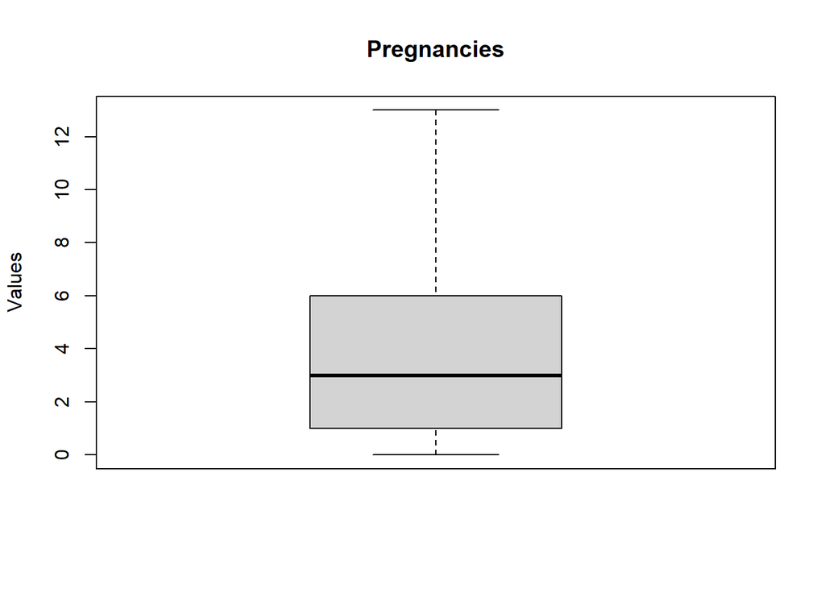

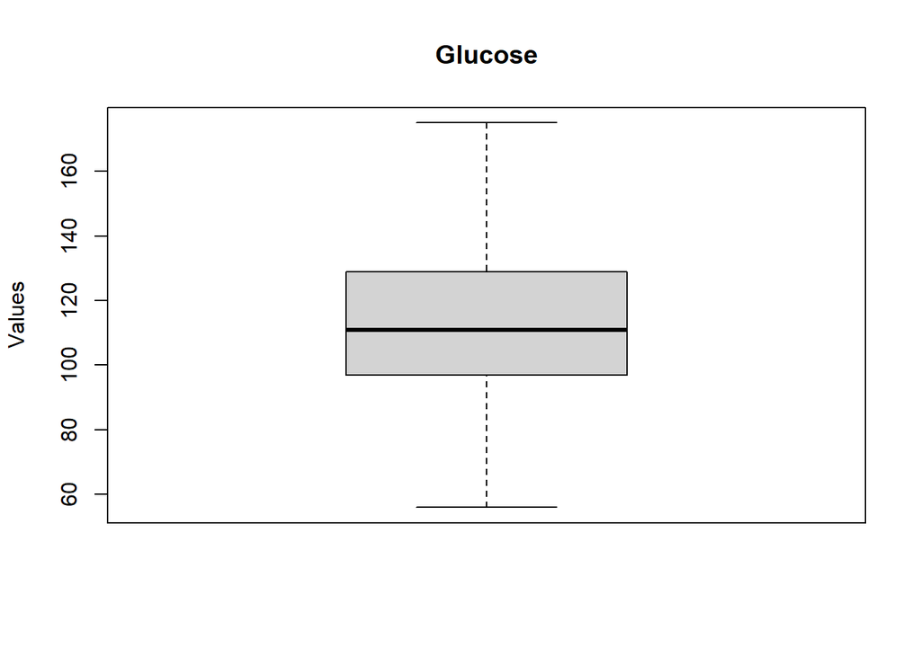

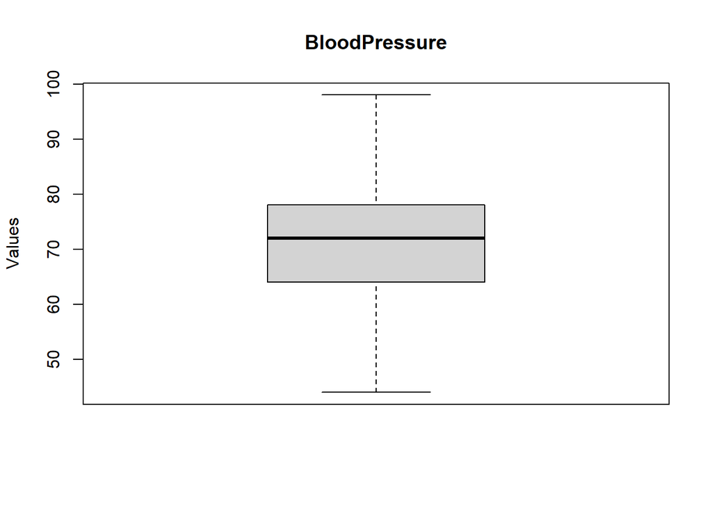

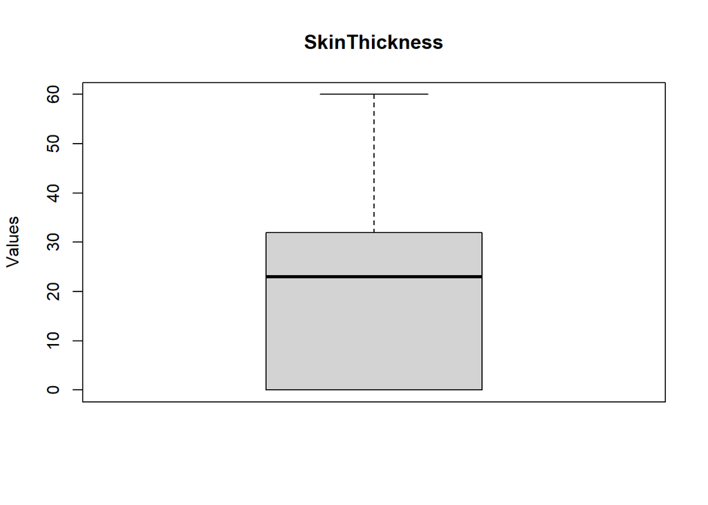

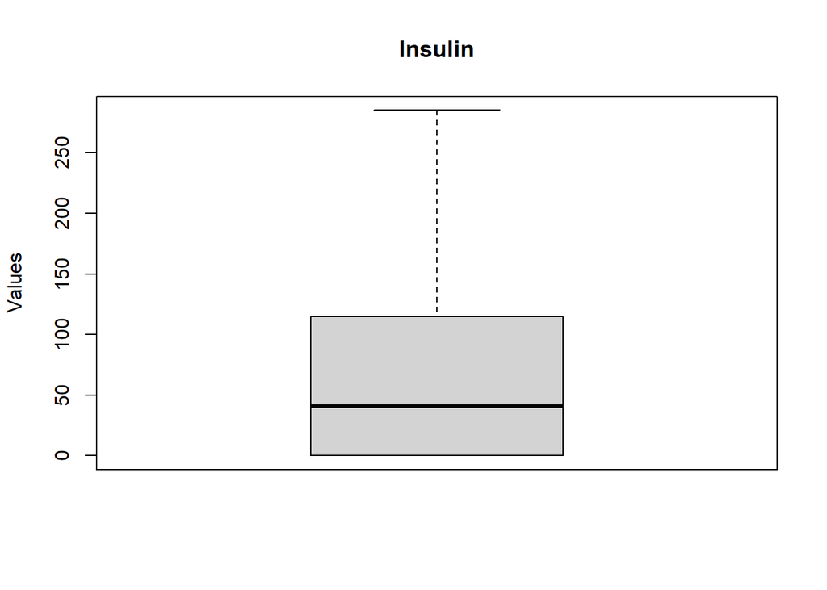

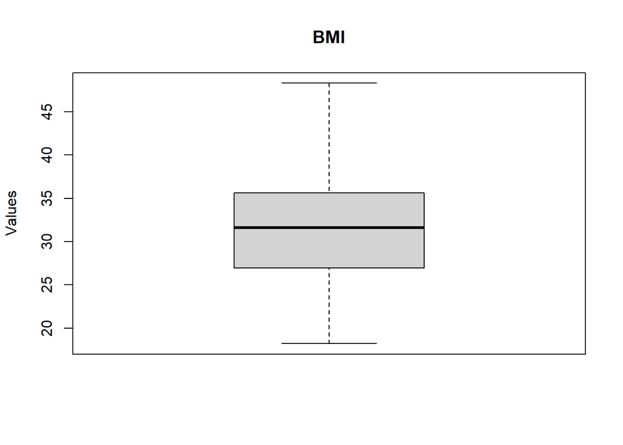

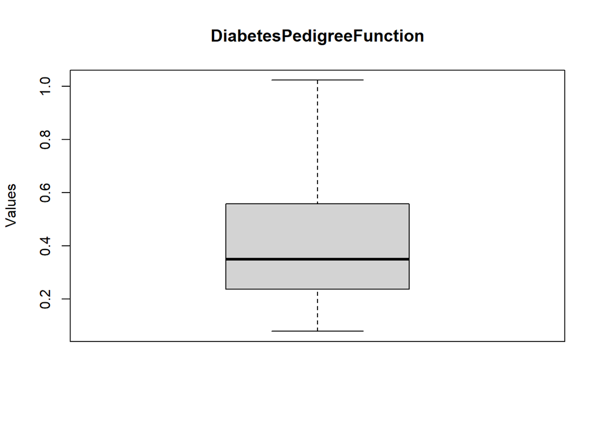

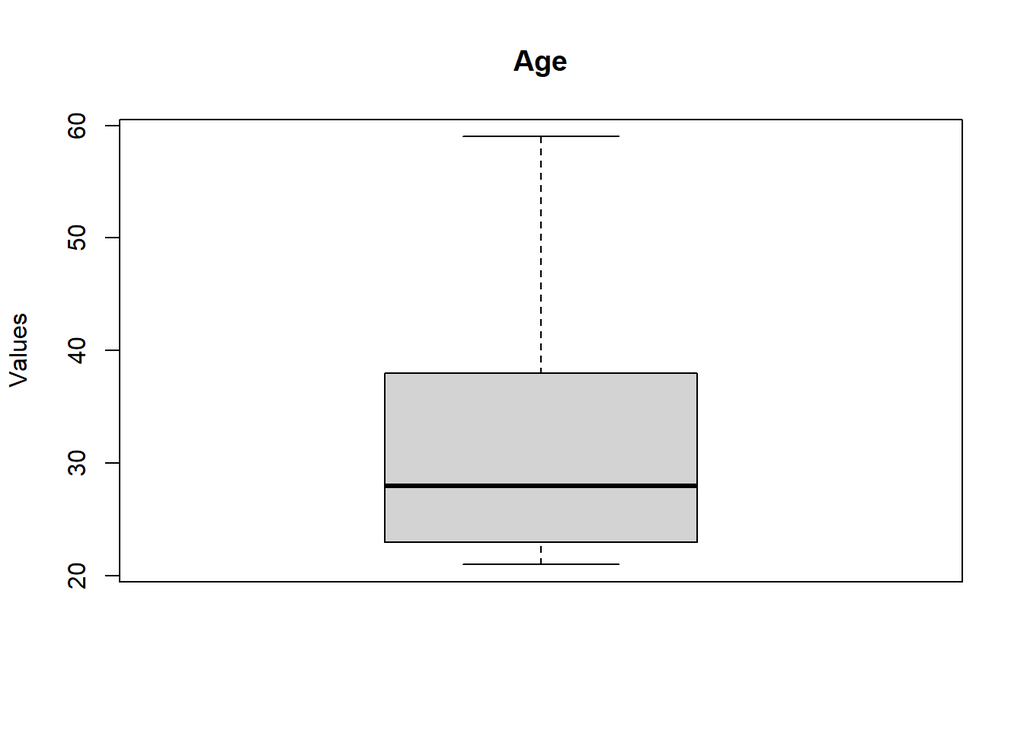

```r
# Boxplot of each feature
for (col in colnames(data)) {
  if (col != "Outcome")
  boxplot(data[[col]], main=col, ylab="Values", outline=TRUE)
}
```

In the above code, we plot new boxplots of every feature after removing outliers from the dataset. As we can see, the new boxplots show no sign of outliers anymore, indicating that our previous method in removing outliers was successful.

```r
# Function for min-max normalization
min_max_normalize <- function(column) {
  min_val <- min(column, na.rm = TRUE)
  max_val <- max(column, na.rm = TRUE)
  normalized_column <- (column - min_val) / (max_val - min_val)
  normalized_column <- round(normalized_column, 3)
  return(normalized_column)
}

# Columns to be normalized
columns_to_normalize <- c("Glucose", "BloodPressure", "SkinThickness", "Insulin")

# Normalize selected columns
data[columns_to_normalize] <- lapply(data[columns_to_normalize], min_max_normalize)
```

In the above code, we apply feature scaling through min-max normalization to variables such as “Glucose”, “BloodPressure”, “SkinThickness”, and “Insulin” so that we can normalize their values to a standard scale of [0.0, 1.0]. The normalized values were then rounded to three decimal places.

```r
# Convert the Pregnancies column to categorical bins
data$Pregnancies <- cut(data$Pregnancies, breaks = c(-Inf, 0, 2, 5, 9, Inf), labels = c("_None", "_Low", "_Moderate", "_High", "_Vhigh"), include.lowest = T)

# Perform one-hot encoding
one_hot_encoded <- model.matrix(~ Pregnancies - 1, data = data)

# Combine the one-hot encoded matrix with the original data
data <- cbind(data, one_hot_encoded)

# Drop the original Pregnancies column
data <- data[, !(names(data) %in% "Pregnancies")]
```

In the above code, we normalize the Pregnancies feature based on the Binning/Discretization method. Five bins of pregnancy ranges were created where Bin 1 contains 0 pregnancies (None), Bin 2 contains 1-2 pregnancies (Low), Bin 3 contains 3-5 pregnancies (Moderate), Bin 4 contains 6-9 pregnancies (High), and Bin 5 contains 10+ pregnancies (Vhigh). The categorical bins were then one-hot encoded to fit the models.

```r
# Convert the BMI column to categorical bins
data$BMI <- cut(data$BMI, breaks = c(-Inf, 18.4, 24.5, 29.9, 34.9, 39.9, Inf), labels = c("_Underweight", "_Normal", "_Overweight", "_Obese_Class1", "_Obese_Class2", "_Obese_Class3"), include.lowest = T)

# Perform one-hot encoding
one_hot_encoded <- model.matrix(~ BMI - 1, data = data)

# Combine the one-hot encoded matrix with the original data
data <- cbind(data, one_hot_encoded)

# Drop the original BMI column
data <- data[, !(names(data) %in% "BMI")]
```

In the above code, we normalize the BMI feature based on the Binning/Discretization method. Six bins of BMI ranges were created where Bin 1 contains values of BMI <= 18.4 (Underweight), Bin 2 contains values of 18.5 <= BMI <= 24.5 (Normal), Bin 3 contains values of 25.0 <= BMI <= 29.9 (Overweight), Bin 4 contains values of 30.0 <= BMI <= 34.9 (Obese Class 1), Bin 5 contains values of 35.0 <= BMI <= 39.9 (Obese Class 2), and Bin 6 contains of BMI >= 40.0 (Obese Class 3). The categorical bins were then one-hot encoded to fit the models.

```r
# Convert the Age column to categorical bins
data$Age <- cut(data$Age, breaks = c(20, 29, 39, 49, Inf), labels = c("_20_29", "_30_39", "_40_49", "_50"), include.lowest = TRUE)

# Perform one-hot encoding
one_hot_encoded <- model.matrix(~ Age - 1, data = data)

# Combine the one-hot encoded matrix with the original data
data <- cbind(data, one_hot_encoded)

# Drop the original BMI column
data <- data[, !(names(data) %in% "Age")]
```

In the above code, we normalize the Age feature based on the Binning/Discretization method. Four bins of age ranges were created where Bin 1 contains 20-29 years of age, Bin 2 contains 30-39 years of age, Bin 3 contains 40-49 years of age, and Bin 4 contains 50+ years of age. The categorical bins were then one-hot encoded to fit the models.

```r
# Correlation matrix
correlation_matrix <- cor(data)
```

In the above code, we compute the correlation matrix for in depth analysis of the correlation between the different variables with respect to the target variable Outcome.

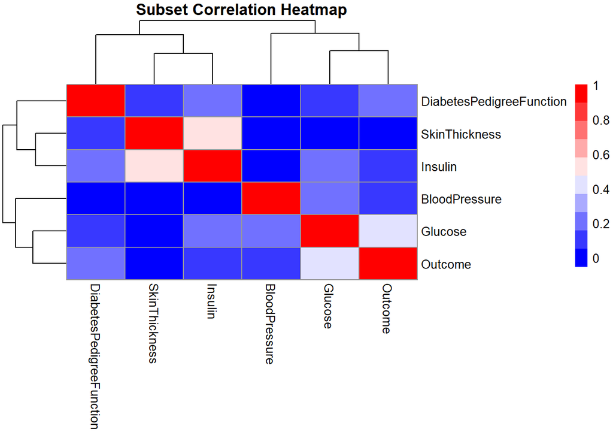

```r
# Subset correlation heatmap
selected_vars <- c("Glucose", "BloodPressure", "SkinThickness", "Insulin", "DiabetesPedigreeFunction", "Outcome")
subset_matrix <- correlation_matrix[selected_vars, selected_vars]
pheatmap(subset_matrix,
         color = colorRampPalette(c("blue", "white", "red"))(10),
         main = "Subset Correlation Heatmap"
)
```

The above heatmap is focused on medical/biological variables such as Diabetes Pedigree Function, Skin Thickness, Insulin, Blood Pressure, Glucose, and an outcome. The Diabetes Pedigree Function seems to have a moderate positive correlation with the outcome. Glucose has the strongest positive correlation with the outcome, suggesting it’s an important factor in whatever the outcome represents. Insulin and Skin Thickness show a neutral to slightly negative correlation with the outcome.

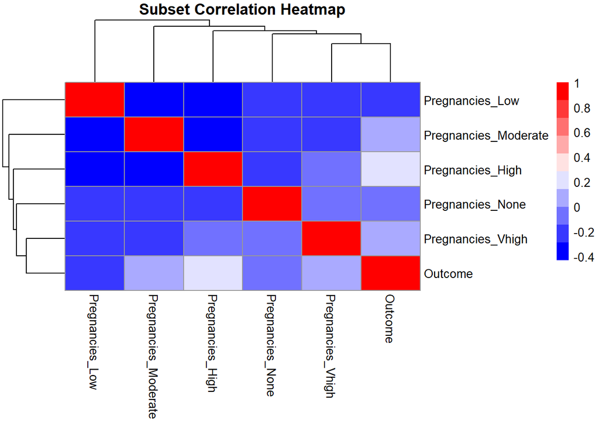

```r
# Subset correlation heatmap
selected_vars <- c("Pregnancies_None", "Pregnancies_Low", "Pregnancies_Moderate", "Pregnancies_High", "Pregnancies_Vhigh", "Outcome")
subset_matrix <- correlation_matrix[selected_vars, selected_vars]
pheatmap(subset_matrix,
         color = colorRampPalette(c("blue", "white", "red"))(10),
         main = "Subset Correlation Heatmap"
)
```

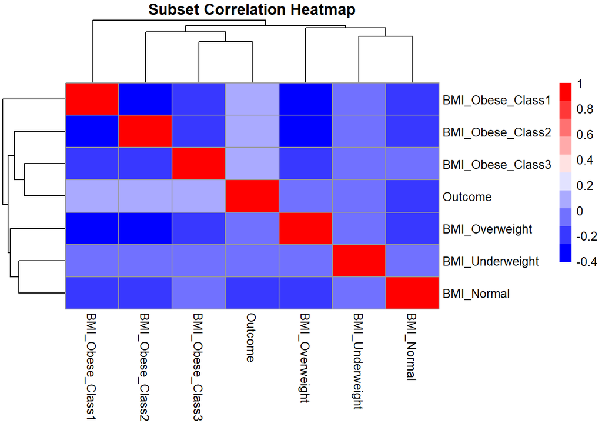

```r
# Subset correlation heatmap
selected_vars <- c("BMI_Underweight", "BMI_Normal", "BMI_Overweight", "BMI_Obese_Class1", "BMI_Obese_Class2", "BMI_Obese_Class3", "Outcome")
subset_matrix <- correlation_matrix[selected_vars, selected_vars]
pheatmap(subset_matrix,
         color = colorRampPalette(c("blue", "white", "red"))(10),
         main = "Subset Correlation Heatmap"
)
```

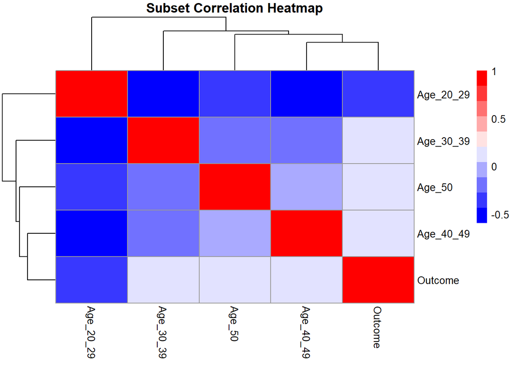

```r
# Subset correlation heatmap
selected_vars <- c("Age_20_29", "Age_30_39", "Age_40_49", "Age_50", "Outcome")
subset_matrix <- correlation_matrix[selected_vars, selected_vars]
pheatmap(subset_matrix,
         color = colorRampPalette(c("blue", "white", "red"))(10),
         main = "Subset Correlation Heatmap"
)
```

# Part 5: Data Splitting

```r
# Set a random seed
set.seed(123)

# Split the dataset
split <- sample.split(data$Outcome, SplitRatio = 0.6)

# Train set
train <- subset(data, split == T)

# Test set
test <- subset(data, split == F)
```

In the above code, we split the dataset using the validation set approach into two sets, a training set (60%), and test set (40%), where a random seed is specified to ensure reproducibility if the code is executed multiple times.

# Part 6: Model Development

```r
# Train the unpruned decision tree
unpruned_tree <- rpart(Outcome ~ ., data = train, method = "class")

# Unpruned tree
printcp(unpruned_tree)
```

```
##
## Classification tree:
## rpart(formula = Outcome ~ ., data = train, method = "class")
##
## Variables actually used in tree construction:
## [1] Age_20_29                BloodPressure            BMI_Normal
## [4] DiabetesPedigreeFunction Glucose                  SkinThickness
##
## Root node error: 89/333 = 0.26727
##
## n= 333
##
##         CP nsplit rel error  xerror     xstd
## 1 0.123596      0   1.00000 1.00000 0.090736
## 2 0.033708      2   0.75281 0.93258 0.088695
## 3 0.028090      4   0.68539 0.96629 0.089740
## 4 0.017978      6   0.62921 1.01124 0.091057
## 5 0.010000     12   0.50562 0.98876 0.090409
```

In the above code, we train an unpruned decision tree model and print its contents.

```r
# Optimal complexity parameter for pruning
cp_value <- unpruned_tree$cptable[which.min(unpruned_tree$cptable[, "xerror"]), "CP"]

# Prune the tree using the complexity parameter
pruned_tree <- prune(unpruned_tree, cp = cp_value)

# Pruned tree
printcp(pruned_tree)
```

```
##
## Classification tree:
## rpart(formula = Outcome ~ ., data = train, method = "class")
##
## Variables actually used in tree construction:
## [1] DiabetesPedigreeFunction Glucose
##
## Root node error: 89/333 = 0.26727
##
## n= 333
##
##         CP nsplit rel error  xerror     xstd
## 1 0.123596      0   1.00000 1.00000 0.090736
## 2 0.033708      2   0.75281 0.93258 0.088695
```

In the above code, we prune the decision tree according to the computed optimal complexity parameter, and then print its contents.

```r
# Make predictions on the test set using the pruned tree
predictions <- predict(pruned_tree, newdata = test, type = "class")

# Convert predicted values to a factor for evaluation
predicted_classes <- as.factor(predictions)
```

In the above code, we make predictions on the test set using the pruned tree model.

```r
# Compute confusion matrix
confusion_matrix <- table(test$Outcome, predicted_classes)
print(confusion_matrix)
```

```
##    predicted_classes
##       0   1
##   0 144  19
##   1  40  20
```

```r
# Calculate accuracy
accuracy <- sum(diag(confusion_matrix)) / sum(confusion_matrix)
accuracy <- round(accuracy, 2)
cat("Accuracy:", accuracy)
```

```
## Accuracy: 0.74
```

```r
# Calculate precision
precision <- confusion_matrix[2, 2] / sum(confusion_matrix[, 2])
precision <- round(precision, 2)
cat("\nPrecision:", precision)
```

```
##
## Precision: 0.51
```

```r
# Calculate recall
recall <- confusion_matrix[2, 2] / sum(confusion_matrix[2, ])
recall <- round(recall, 2)
cat("\nRecall:", recall)
```

```
##
## Recall: 0.33
```

```r
# Calculate F1 score
f1_score <- 2 * (precision * recall) / (precision + recall)
f1_score <- round(f1_score, 2)
cat("\nF1 Score:", f1_score)
```

```
##
## F1 Score: 0.4
```

In the above codes, we evaluate the performance of this model by computing its confusion matrix, accuracy, precision, recall, and f1 score values.

```r
# Train the Random Forest model
model <- randomForest(Outcome ~ ., data = train)

# Make predictions on the test set
predictions <- predict(model, newdata = test)
```

In the above code, we train and test a Random Forest model on the dataset.

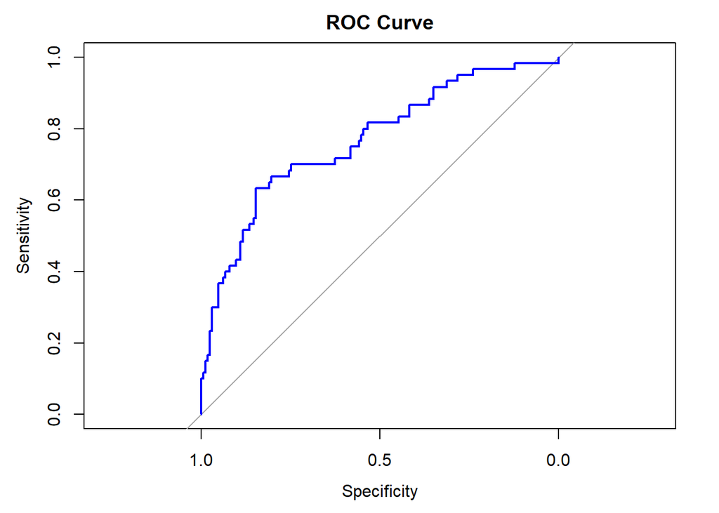

```r
# Calculate and plot ROC curve
roc_curve <- roc(test$Outcome, as.numeric(predictions))
plot(roc_curve, main = "ROC Curve", col = "blue", lwd = 2)
```

```r
# Calculate AUC value
auc_value <- auc(roc_curve)
cat("AUC:", round(auc_value, 2))
```

```
## AUC: 0.77
```

In the above codes, we evaluate the model’s performance by plotting its ROC curve and calculating its AUC value. Evaluation metrics such as confusion matrix, accuracy, precision, recall, and f1 score were not calculated since such metrics are very sensitive to class imbalance which is the case in our test set.

```r
# Train the SVM model
model <- svm(Outcome ~ ., data = train, kernel = "poly", degree = 2, cost = 1, gamma = 1)

# Make predictions on the test set
predictions <- predict(model, newdata = test)
```

In the above code, we train and test an SVM model on the dataset.

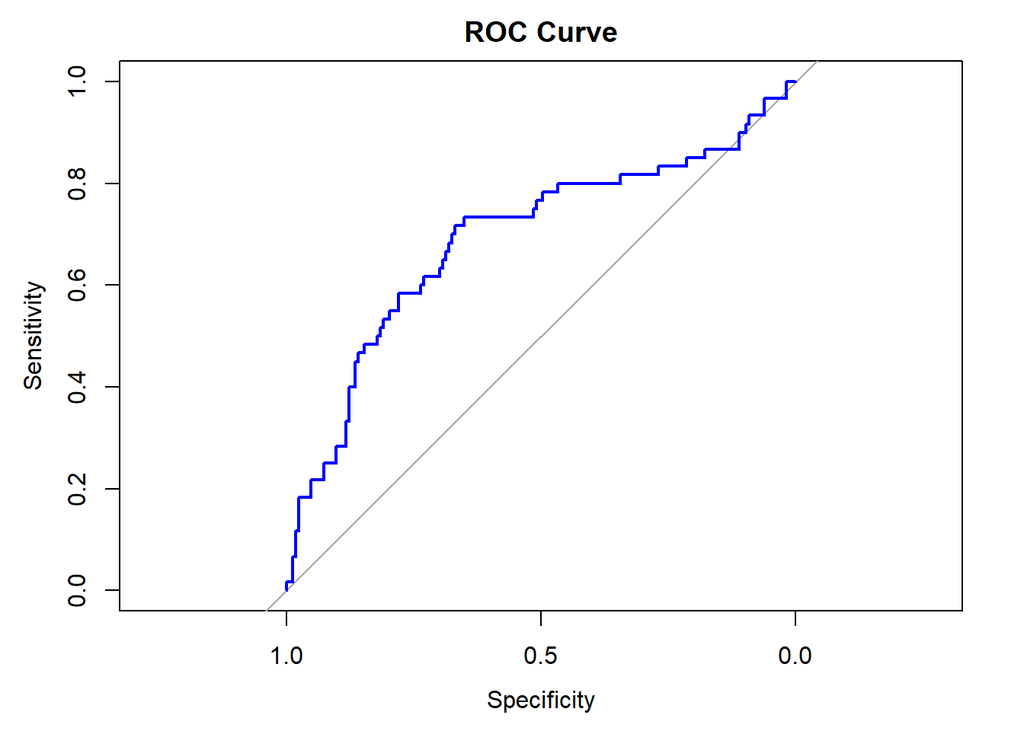

```r
# Calculate and plot ROC curve
roc_curve <- roc(test$Outcome, as.numeric(predictions))
plot(roc_curve, main = "ROC Curve", col = "blue", lwd = 2)
```

```r
# Calculate AUC value
auc_value <- auc(roc_curve)
cat("AUC:", round(auc_value, 2))
```

```
## AUC: 0.69
```

In the above codes, we use evaluation metrics such as plotting the model’s ROC curve and calculating its AUC value (for the same reason mentioned previously).

```r
# Set a random seed
set.seed(123)

# Select features for clustering
features <- data[, c("Glucose", "BloodPressure", "SkinThickness", "Insulin", "DiabetesPedigreeFunction", "Pregnancies_None", "Pregnancies_Low", "Pregnancies_Moderate", "Pregnancies_High", "Pregnancies_Vhigh", "BMI_Underweight", "BMI_Normal", "BMI_Overweight", "BMI_Obese_Class1", "BMI_Obese_Class2", "BMI_Obese_Class3", "Age_20_29", "Age_30_39", "Age_40_49", "Age_50")]

# Specify number of clusters (k)
k <- 2

# Train the k-means model
model <- kmeans(features, centers = k)

# Predict cluster assignments for the entire dataset
cluster_assignments <- model$cluster
```

In the above code, we apply a k-means clustering model on the dataset with k = 2 (number of clusters).

```r
# Calculate inertia
inertia <- model$tot.withinss
print(paste("Inertia:", inertia))
```

```
## [1] "Inertia: 1122.39375721632"
```

```r
# Calculate silhouette score
silhouette_score <- silhouette(cluster_assignments, dist(features))
print(paste("Silhouette Score:", mean(silhouette_score[, 3])))
```

```
## [1] "Silhouette Score: 0.153832675906302"
```

In the above codes, to evaluate the performance of the k-means, the inertia (how far the points within a cluster are from the centroid of that cluster) and silhouette score (how similar an object is to its own cluster compared to other clusters) were calculated. Generally, a lower inertia value indicate tighter clusters, and a higher silhouette score indicate well-seperated clusters.

# Part 7: Hyperparameter Tuning

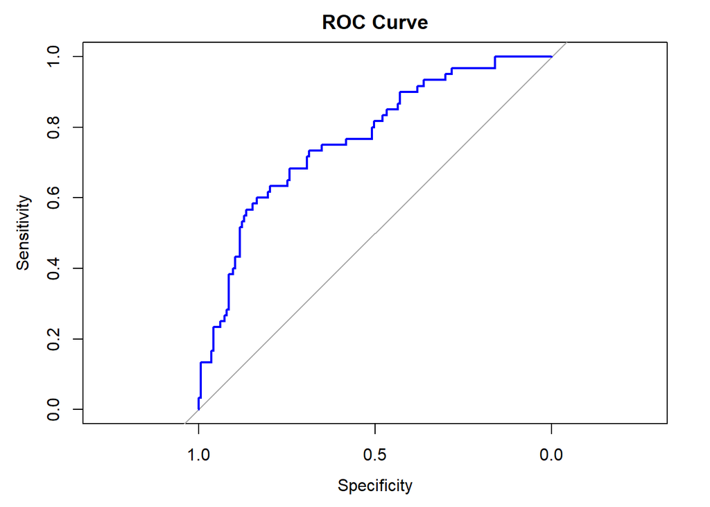

```r
# Train the SVM model
model <- svm(Outcome ~ ., data = train, kernel = "poly", degree = 3, cost = 0.1, gamma = 0.05)

# Make predictions on the test set
predictions <- predict(model, newdata = test)

# Calculate and plot ROC curve
roc_curve <- roc(test$Outcome, as.numeric(predictions))
plot(roc_curve, main = "ROC Curve", col = "blue", lwd = 2)
```

```r
# Calculate AUC value
auc_value <- auc(roc_curve)
cat("AUC:", round(auc_value, 2))
```

```
## AUC: 0.77
```

In the above codes, we tune the hyperparamaters of SVM (kernel, degree, cost, and gamma) to improve its performance. The best parameter values we observed that gave us the best AUC value (0.77 from 0.69) were a polynomial kernel, a cubic degree, a cost of 0.1, and a gamma value of 1/n where n is the number of features (1/n = 0.05 in our case).

# Part 8: Results Interpretation

In conclusion, both Random Forest and SVM stand out as the best models here. An SVM model can be considered over a Random Forest model here due to the fact that Random Forests are often considered as “black-box” models, meaning they provide accurate predictions but may lack interpretability. On the other hand, SVMs can offer more interpretability in terms of understanding the influence of each feature on the classification.